# Racial Inequality in Wages

Case Study 2

Author

Leah Levensailor

Published

November 16, 2025

# Introduction to the Problem

A persistent racial disparity within the American labor market is the wage gap between Black and white individuals. This study analyses data from 25,631 male respondents in the March 1988 Current Population Survey (CPS), examining whether Black men continue to earn less than non-Black men with comparable qualifications after controlling for factors such as years of education, work experience, and region.

The United States Census Bureau hypothesizes that wage disparities among Black workers may vary by region. This study will:

1. Establish a model that allows racial effects to vary across regions while adjusting the influence of education and work experience;
2. Estimate the wage gap between Black and non-Black workers in each region;
3. Conduct hypothesis tests to determine whether these regional wage gaps are statistically significant;
4. Ultimately answer whether Black men indeed earn less after controlling for region, education, and work experience.

# Data Description

We use a dataset from the CPS, which includes the following variables:

1. Wage: Weekly earnings
2. Education: Years of schooling
3. Experience: Years of work experience
4. Black: Black or African American (1=Yes, 0=No)
5. SMSA: Residing in a Standard Metropolitan Statistical Area (i.e., city or vicinity)
6. Region: Region (NE=Northeast, MW=Midwest, S=South, W=West)

```r
# Load necessary packages
library(tidyverse)
library(broom)
library(kableExtra)
library(ggplot2)
library(patchwork)
```

```r
# Load data set
wages <- Sleuth2::ex1029

# Represent indicator variables and set reference levels
wages <- wages|>
  mutate(Region = factor(Region)) |>
  mutate(Region = relevel(Region, ref="MW"))
levels(wages$Region)
```

```
[1] "MW" "NE" "S"  "W"
```

```r
wages <- wages|>
  mutate(Black = factor(Black)) |>
  mutate(Black = relevel(Black, ref="No"))
levels(wages$Black)
```

```
[1] "No"  "Yes"
```

Now lets see some summary statistics:

```r
# Obtaining summary statistics
summary_stats <- wages |>
  summarise(
    Observations = n(),
    Mean_Wage = mean(Wage),
    SD_Wage = sd(Wage),
    Mean_Education = mean(Education),
    Mean_Experience = mean(Experience),
  )

# Create a table for the summary statistics
summary_stats |>
  kbl(caption = "Summary Statistics") |>
  kable_classic()
```

Summary Statistics

| Observations | Mean_Wage | SD_Wage | Mean_Education | Mean_Experience |
| --- | --- | --- | --- | --- |
| 25631 | 640.1625 | 444.2833 | 13.07627 | 18.58656 |

The above table shows that the dataset consists of 25,631 male respondents from the March 1988 Current Population Survey. Summary statistics reveal that the average weekly wage was approximately $640.16 (in 1992 dollars) with substantial variation (SD = $444.28). The typical respondent had completed about 13 years of education and possessed nearly 19 years of work experience.

Now Let’s visualize the distribution of some key variables:

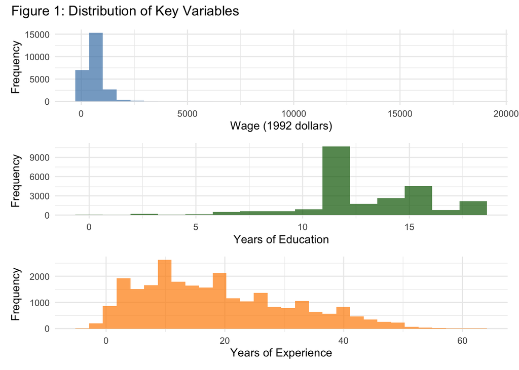

```r
# Figure 1: Distribution of Key Variables
p1 <- ggplot(wages, aes(x = Wage)) +
  geom_histogram(fill = "steelblue", alpha = 0.7, bins = 30) +
  labs(title = "Distribution of Weekly Wages",
       x = "Wage (1992 dollars)", y = "Frequency") +
  theme_minimal()

p2 <- ggplot(wages, aes(x = Education)) +
  geom_histogram(fill = "darkgreen", alpha = 0.7, bins = 15) +
  labs(title = "Distribution of Education Years",
       x = "Years of Education", y = "Frequency") +
  theme_minimal()

p3 <- ggplot(wages, aes(x = Experience)) +
  geom_histogram(fill = "darkorange", alpha = 0.7, bins = 30) +
  labs(title = "Distribution of Experience Years",
       x = "Years of Experience", y = "Frequency") +
  theme_minimal()

# Combine the distribution plots
(p1 + labs(title = NULL)) /
(p2 + labs(title = NULL)) /
(p3 + labs(title = NULL)) +
  plot_annotation(title = "Figure 1: Distribution of Key Variables")
```

Figure 1 displays the distributions of three key continuous variables:

**Weekly Wages**: The wage distribution exhibits strong right-skewness, with most respondents earning below $1,500 weekly but a long tail extending beyond $2,000. This pattern is characteristic of income data and suggests logarithmic transformation may be appropriate for subsequent modeling.

**Years of Experience**: Experience displays a right-skewed distribution, with most workers having between 5-30 years of experience and fewer individuals at the extreme ends of the career spectrum.

# Assessing Conditions For MLR

We first establish a multiple linear regression model, and use several plots to assess conditions.

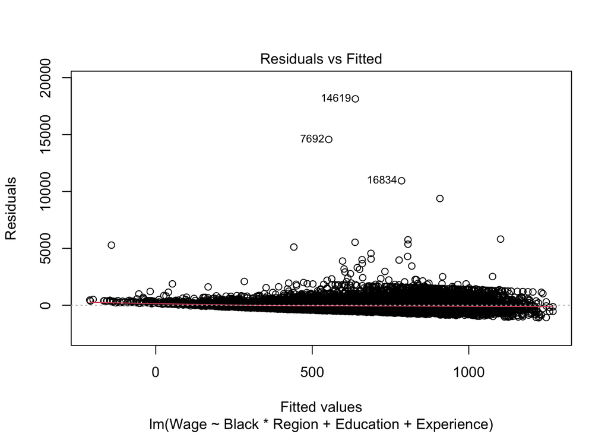

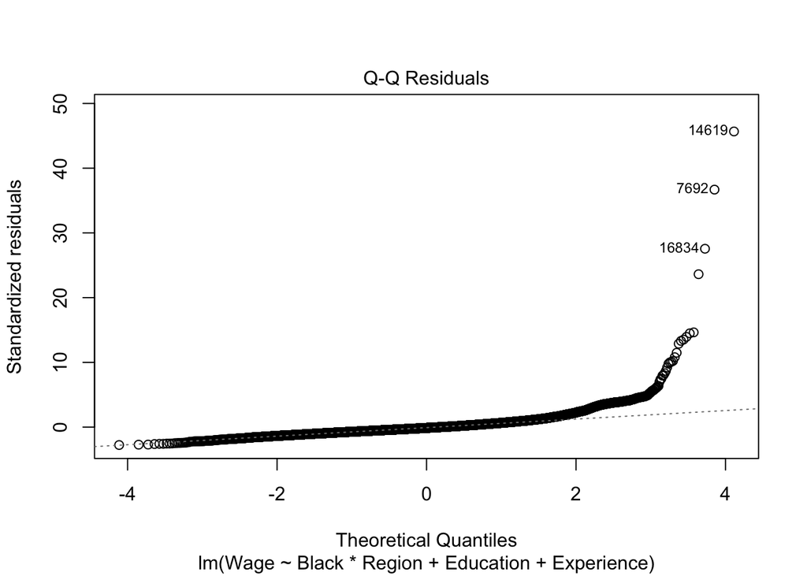

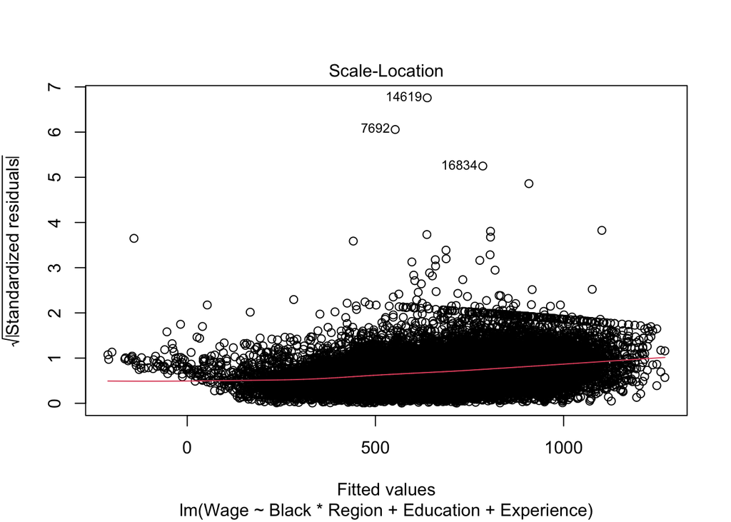

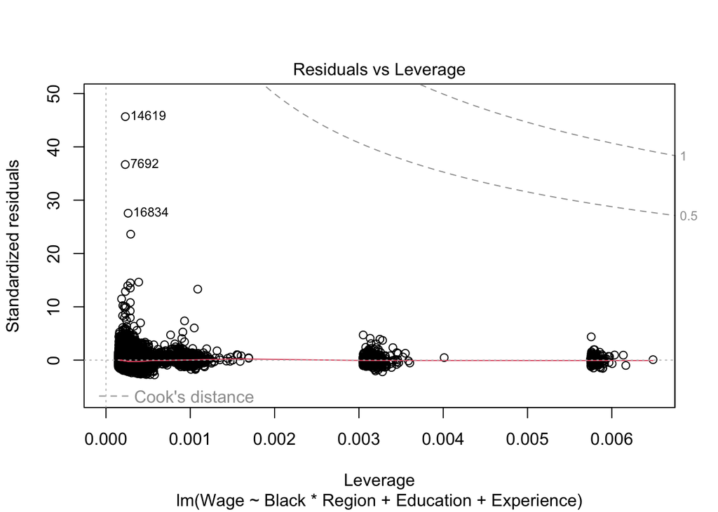

```r
model_interaction <- lm(
  Wage ~ Black * Region + Education + Experience,
  data = wages
)

plot(model_interaction)
```

We can see that the residual plot shows that the variance is larger when the fitted value of y is larger, so the equal variance condition is not satisfied. In the Q-Q plot, the high end deviates significantly from the reference line. It means that the linear regression model that we constructed may not be a good choice, and we may consider the log transformation.

# Modeling Process

## Constructing and Fitting the Model

```r
# Construct a model with log-transformed response variable
model_interaction_log <- lm(
  log(Wage) ~ Black * Region + Education + Experience,
  data = wages
)
```

Let $\text{Wage}_i$ denote the wage of individual $i$. Our final log-linear regression model is:

$$E[\log(\text{Wage}_i) \mid X_i] =
\beta_0 + \beta_1 \text{Black}_i + \beta_2 \text{RegionNE}_i
+ \beta_3 \text{RegionS}_i + \beta_4 \text{RegionW}_i$$

$$+ \beta_5 \text{Education}_i + \beta_6 \text{Experience}_i
+ \beta_7 (\text{Black}_i \times \text{RegionNE}_i)
+ \beta_8 (\text{Black}_i \times \text{RegionS}_i)
+ \beta_9 (\text{Black}_i \times \text{RegionW}_i).$$

The coefficient $\beta_1$ represents the multiplicative effect of being Black on the median wage, holding all other variables fixed.  
Interaction terms imply that the effect of being Black may differ across regions, with the multiplicative effect in region $k$ given by $\exp(\beta_1 + \beta_k)$, where $\beta_k$ is the corresponding interaction coefficient.

The estimation of the parameters is shown below in the table.

```r
# Converting model output to a tidy dataframe
interaction_lm_table <- model_interaction_log |>
  broom::tidy()

# Creating a nicely formatted regression table using kable
interaction_lm_table |>
  knitr::kable(
    digits = 4
  )
```

| term | estimate | std.error | statistic | p.value |
| --- | --- | --- | --- | --- |
| (Intercept) | 4.6601 | 0.0195 | 239.2107 | 0.0000 |
| BlackYes | -0.1928 | 0.0307 | -6.2866 | 0.0000 |
| RegionNE | 0.0607 | 0.0100 | 6.0785 | 0.0000 |
| RegionS | -0.0548 | 0.0095 | -5.7507 | 0.0000 |
| RegionW | 0.0034 | 0.0101 | 0.3330 | 0.7391 |
| Education | 0.0989 | 0.0012 | 81.9261 | 0.0000 |
| Experience | 0.0183 | 0.0003 | 64.9916 | 0.0000 |
| BlackYes:RegionNE | -0.0035 | 0.0432 | -0.0817 | 0.9349 |
| BlackYes:RegionS | -0.0418 | 0.0350 | -1.1916 | 0.2334 |
| BlackYes:RegionW | 0.0382 | 0.0514 | 0.7429 | 0.4575 |

## Assessing Conditions For Log-transformed Model

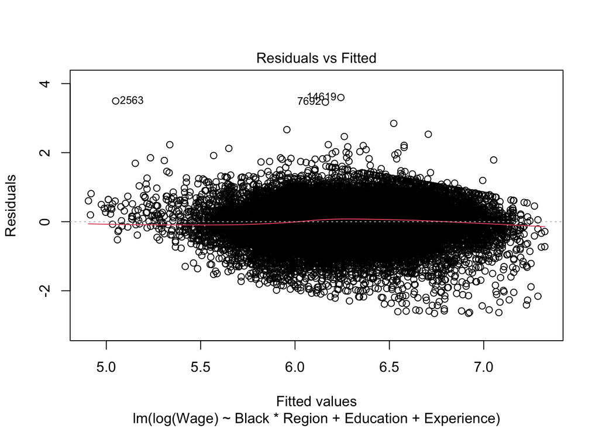

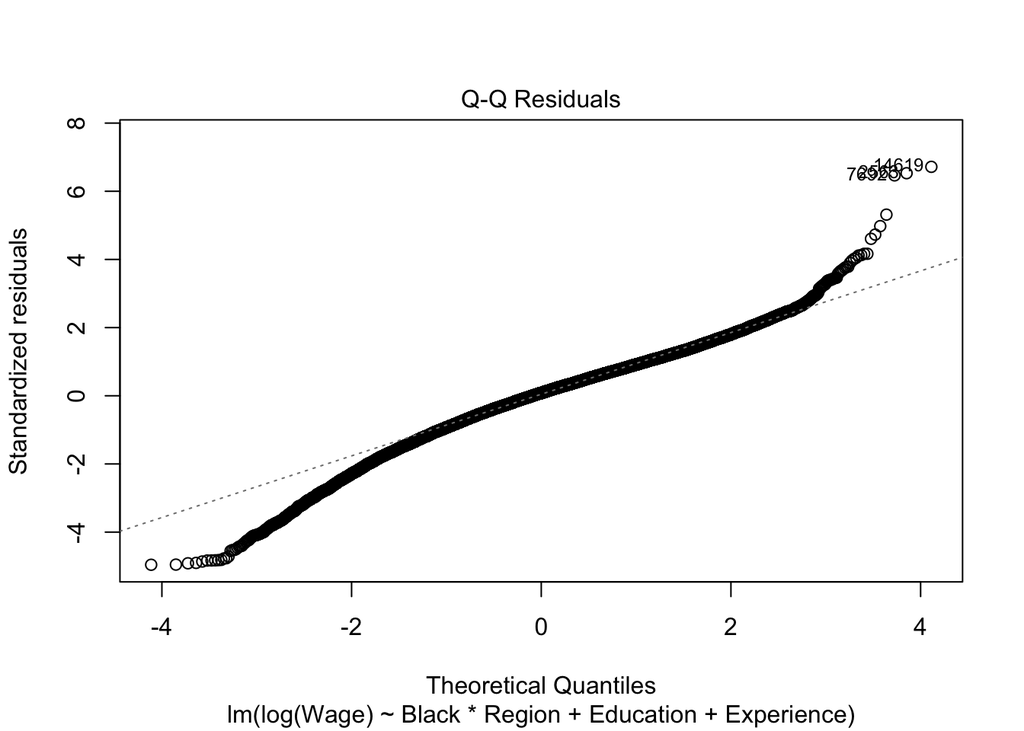

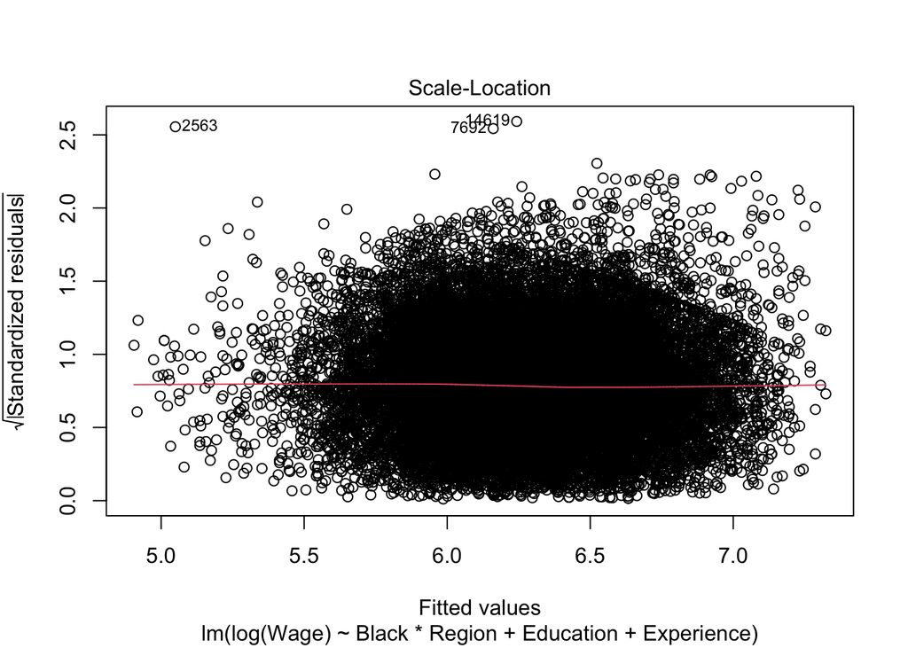

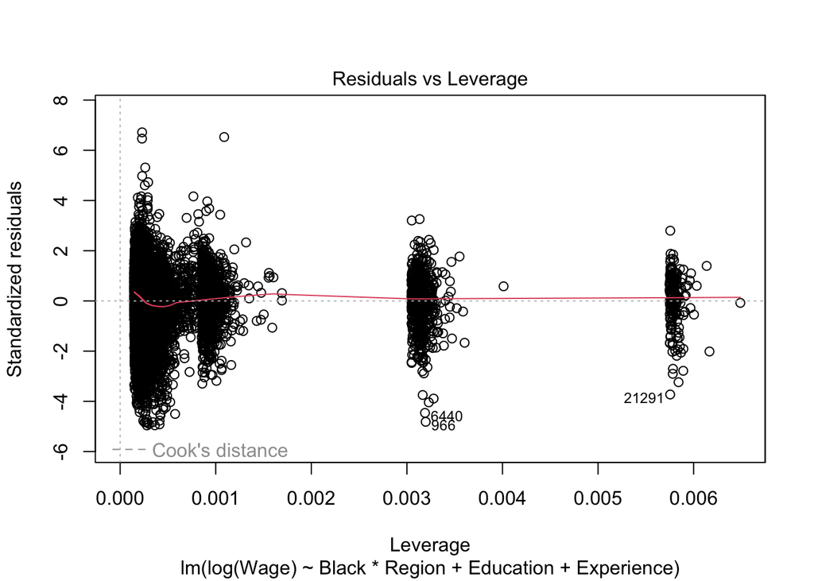

```r
# Check condition for log-transformed model
plot(model_interaction_log)
```

While the log-transformed model shows some improvement over the original scale model, it still exhibits some limitations. The residual plot reveals some heteroscedasticity, with variance first increases then decreases when the fitting value y is larger, and the Q-Q plot shows slight deviations from normality in the tails. However, these departures are less severe than in the original model, where clear heteroscedasticity and extreme non-normality violated core regression assumptions. Therefore, we will continue to use the log-transformed model in our study.

## ANOVA and Results

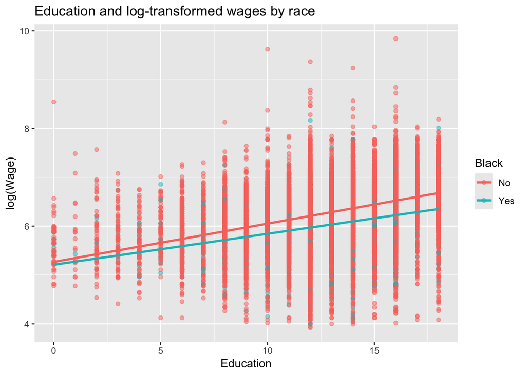

```r
wages |>
  ggplot(aes(x = Education, y = log(Wage), color = Black)) +
  geom_point(alpha = 0.5) +
  geom_smooth(method = "lm", se = FALSE) +
  ggtitle("Education and log-transformed wages by race")
```

The graph above shows how Education and Wage relate with respect to race. The explanatory variable here is Education

```r
# Tidy and format output
model_interaction_log |>
  tidy() |>
  kable(digits = c(NA, 3, 3, 2, 4))
```

| term | estimate | std.error | statistic | p.value |
| --- | --- | --- | --- | --- |
| (Intercept) | 4.660 | 0.019 | 239.21 | 0.0000 |
| BlackYes | -0.193 | 0.031 | -6.29 | 0.0000 |
| RegionNE | 0.061 | 0.010 | 6.08 | 0.0000 |
| RegionS | -0.055 | 0.010 | -5.75 | 0.0000 |
| RegionW | 0.003 | 0.010 | 0.33 | 0.7391 |
| Education | 0.099 | 0.001 | 81.93 | 0.0000 |
| Experience | 0.018 | 0.000 | 64.99 | 0.0000 |
| BlackYes:RegionNE | -0.004 | 0.043 | -0.08 | 0.9349 |
| BlackYes:RegionS | -0.042 | 0.035 | -1.19 | 0.2334 |
| BlackYes:RegionW | 0.038 | 0.051 | 0.74 | 0.4575 |

```r
# Test if pay gaps differ by region
anova(model_interaction_log)
```

```
Analysis of Variance Table

Response: log(Wage)
                Df Sum Sq Mean Sq   F value Pr(>F)
Black            1  170.7  170.73  594.9801 <2e-16 ***
Region           3   91.8   30.60  106.6532 <2e-16 ***
Education        1 1257.7 1257.72 4382.9684 <2e-16 ***
Experience       1 1213.2 1213.23 4227.9287 <2e-16 ***
Black:Region     3    1.2    0.42    1.4489 0.2264
Residuals    25621 7352.1    0.29
---
Signif. codes:  0 '***' 0.001 '**' 0.01 '*' 0.05 '.' 0.1 ' ' 1
```

Looking at the ANOVA test we can see that each of th explanatory variables are statistically significant except for the interaction between if the person identified as Black and the region. Since the ANOVA showed there was no statistical relationship we now want to look at the actual wage difference for each reagion and race holding for education and experience.

```r
# Predict wages for Black and non-Black workers in each region
predict_df <- expand.grid(
  Black = levels(wages$Black),
  Region = levels(wages$Region),
  Education = mean(wages$Education, na.rm = TRUE),
  Experience = mean(wages$Experience, na.rm = TRUE)
)

predict_df$logWage <- predict(model_interaction_log, newdata = predict_df)
predict_df$Wage <- exp(predict_df$logWage)

# View region-specific wage estimates
predict_df
```

```
  Black Region Education Experience  logWage     Wage
1    No     MW  13.07627   18.58656 6.293260 540.9137
2   Yes     MW  13.07627   18.58656 6.100459 446.0625
3    No     NE  13.07627   18.58656 6.353951 574.7593
4   Yes     NE  13.07627   18.58656 6.157623 472.3041
5    No      S  13.07627   18.58656 6.238463 512.0709
6   Yes      S  13.07627   18.58656 6.003899 405.0048
7    No      W  13.07627   18.58656 6.296639 542.7445
8   Yes      W  13.07627   18.58656 6.142045 465.0036
```

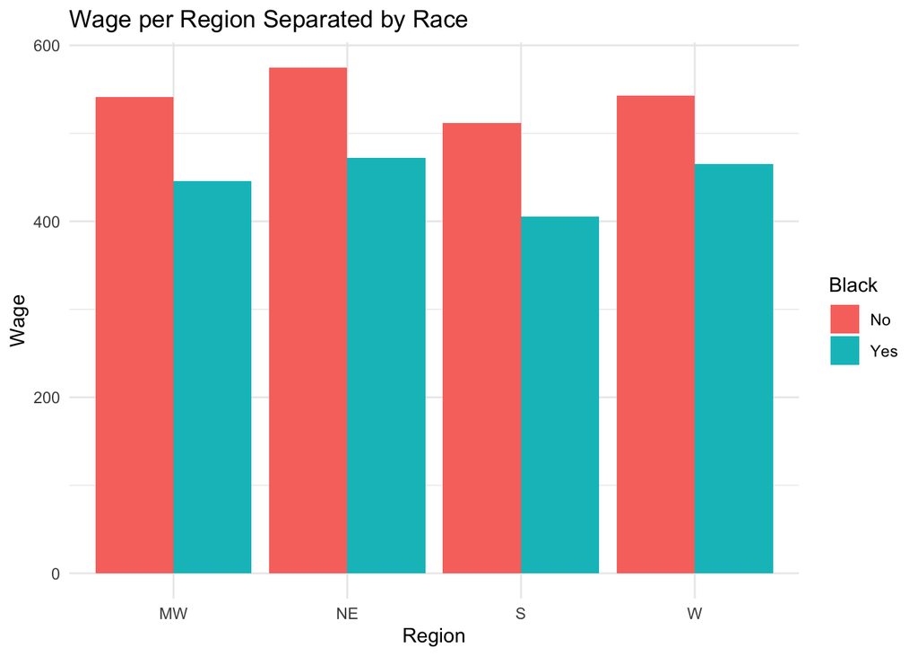

```r
ggplot(predict_df, aes(x = Region, y = Wage, fill = Black)) +
  geom_col(position = "dodge") +
  labs(title = "Wage per Region Separated by Race") +
  theme_minimal()
```